# Project Report

Simon Antwi and Steven Durtka

2024-12-5

### The impact of Migration on Housing Prices in the US

### Motivation

Migration is the movement of people from one place to another. This can happen internationally when people move from one country to another, or it can happen internally as people move within the same country.Migration can be temporary or permanent, voluntary or forced.It can also be seasonal.

Numerous factors, such as economic opportunities, escaping conflict or persecution, reuniting with family, or educational purposes, inform migration decisions for people moving between nations. Family, employment, educational pursuits, or other interests are some of the underlying reasons people may choose to relocate within the U.S.

Housing prices stand for the cost of purchasing properties, such as houses, apartments, or condominiums. Migration significantly impacts all facets of the US economy, including the housing market. We want to investigate the impact of migrants’ influx (both domestic and foreign) on local housing prices, considering also the demand and supply factors in the market such as interest rates and general population increases.

### Why It Matters

Firstly, it is crucial for policymakers as it aids them in making informed decisions regarding migration, which in turn helps to stabilize housing prices, ensuring affordability and a high standard of living.

Furthermore, it can facilitate the establishment of a stable market, as both homeowners and renters have a reasonable insight into the fluctuations in the housing market.

Finally, it can also function as a guide for urban planning and infrastructure development.

### Research Questions

1. What is the relationship between migration and housing prices. (Descriptive, Predictive)
2. How does the effect on housing prices vary according to counties? (Descriptive)
3. The distribution patterns of migration and housing prices across states and time. (Descriptive)
4. The impact of urbanization driven by migration on housing prices. (Descriptive)

### Data Description

#### Migration Data Sets

(https://www.irs.gov/statistics/soi-tax-stats-migration-data-2013-2020) The Internal Revenue Service (IRS) provided the data. The migration is based on year-to-year address changes reported on individual income tax returns filed with the IRS. We use county-level data from 2013 to 2020. The migration data consists of both the inflows and outflows of people within and outside the country. N1 is the number of returns filed, approximating the number of migrated households. N2: number of personal exemptions claimed. Which approximates the number of individuals. The size of adjusted gross income (AGI) and the age of the primary taxpayer determine Agi, the aggregate migration flow at the state level. It is reported in thousands of dollars.

#### Prime Interest Rates

The control variable is interest rate from 2013 to 2020. The interest rates were scraped from the JP Morgan Bank website and averaged by year.

### How Migration data and Housing data are related.

There is a close relationship between migration data and the housing data set. Migration patterns can directly influence the demand for housing. Areas facing elevated levels of immigration may see increased development to meet demand. This can affect housing prices depending on how fast supply can catch up.

The two data sets were merged by year and the state and county FIPS code.

### Data Processing

#### Migration Data

There were no missing values. We changed the column names to make them more descriptive. We kept only county-level inflow data in the data set. Each year has its own file. Because the migration data is based on tax return filings, it may not accurately reflect the actual migration into the county, as some individuals who move in and out may not file a tax return.

#### Housing Prices Data

The Federal Housing Finance Agency “suppressed” some housing prices for counties with fewer than five values, even though we had no missing values. However, since our focus is on the housing market, we used all data from purchase prices in the data set for housing values, excluding refinance appraisals. The final data set included only data for the fifty states and the District of Columbia. We subset the housing price data by year, using the state and county FIPS codes as keys to join each year’s migration data. We bound all the years into a single data frame for analysis, adding the average prime interest rate for each year as a separate column. The skewed distributions of both the migration and housing price data prompted a log transformation.

### Exploratory Analysis

#### Finding 1: The relationship between migration and housing prices

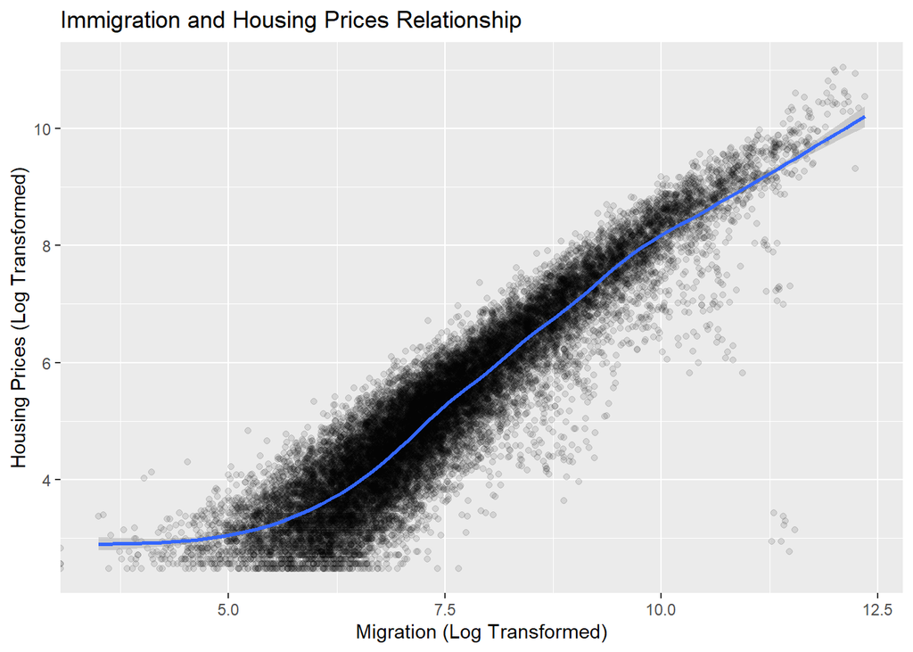

#### Finding 2: How does the effect on housing prices vary according to counties? (Descriptive)

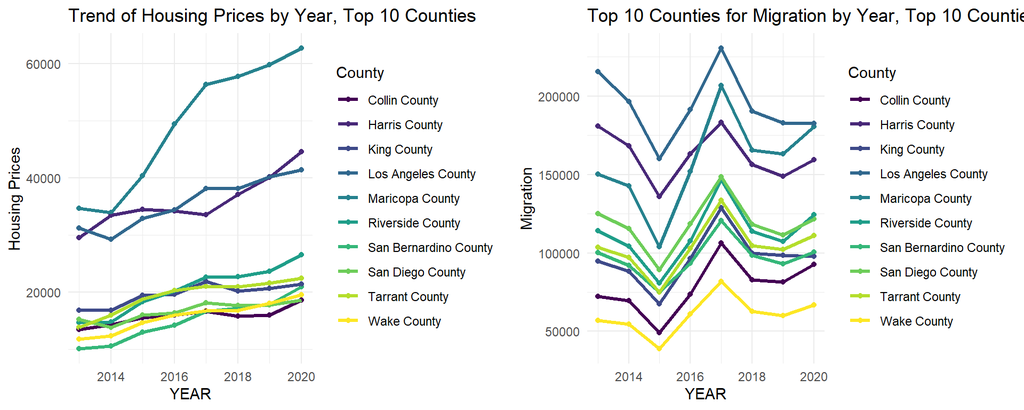

#### Finding 3: The distribution patterns of migration and housing prices across states and time. (Descriptive)

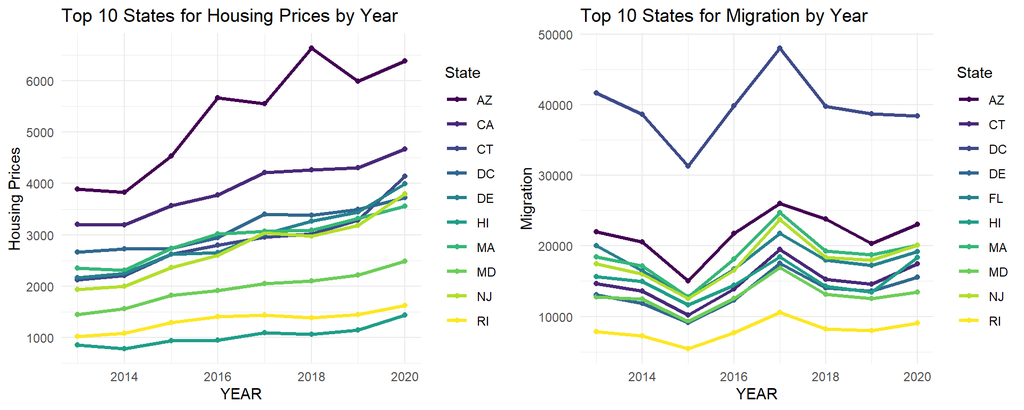

From the graph above, States like Arizona (AZ) and Florida (FL) show consistently high migration levels, peaking around 2017 before declining. Migration trends might be influenced by factors like affordability, job opportunities, and quality of life.

#### Finding 4: Impact of urbanization on migration and housing prices

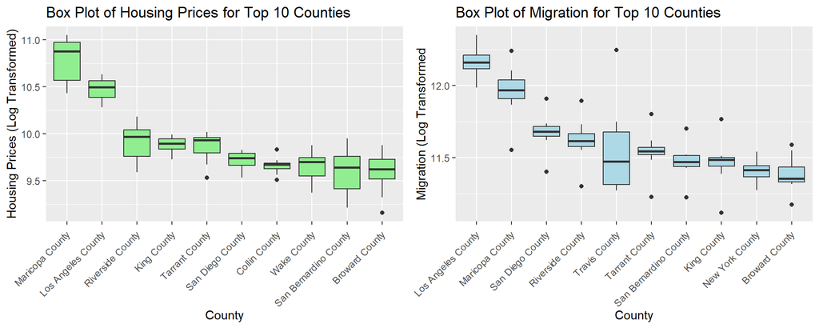

The boxes show the interquartile range (IQR), which is the range from the 25th percentile (bottom edge of the box) to the 75th percentile (top edge of the box).The line within each box represents the median house price for that county. Whiskers extend from the box to indicate the range of house prices within 1.5 times the IQR. Individual dots represent potential outliers that fall outside this range.

The migration box plot above provides a summary of the migration for the top 10 counties. Los Angeles County leads with the highest median migration levels, followed by Maricopa County and San Diego County. Counties like New York County and Broward County show lower median migration and a narrower range, suggesting more consistent migration numbers with fewer outliers.

The two diagrams highlight key factors in urbanization, which is brought about by the relationship between migration and housing prices. As was shown for Maricopa and Riverside Counties, rapid population inflow means a greater demand for housing and increased prices. This shows how economic opportunities are concentrated in urban areas. On the other hand, counties such as San Bernardino, with a relatively low housing cost but high migration, are a result of the spillover effect of urbanization. These areas likely represent the suburban areas of larger cities and thus offer relatively more affordable housing without losing the benefits of proximity to the city center.